# Differential binding analysis

John Blischak

**Last updated:** 2015-10-22

**Code version:** 044491cd5df4302bbdcf97ec1313fa184fc31516

```r
library("knitr")
opts_chunk$set(fig.align = "center", fig.width = 10)
```

## Setup

Load packages.

```r
library("ggplot2")
library("ChIPQC")
library("DiffBind")
```

Load annotation file.

```r
anno <- read.table("../../data/yeast/annotation.txt", sep = "\t",
            header = TRUE, stringsAsFactors = FALSE)
anno
```

```
##        ip        set1 replicate                 sample   total  mapped
## 1 H3K4me3  aa762_1080        r1  H3K4me3.aa762_1080.r1 2996627 2780365
## 2 H3K4me3  aa762_1080        r2  H3K4me3.aa762_1080.r2 4670790 4212929
## 3 H3K4me3 full_length        r1 H3K4me3.full_length.r1 3931575 3605503
## 4 H3K4me3 full_length        r2 H3K4me3.full_length.r2 4658812 3818560
## 5   input full_length        r1   input.full_length.r1 3349887 2987036
## 6   input  aa762_1080        r1    input.aa762_1080.r1 2858605 2371804
##   mapped_quality non_duplicated
## 1        2490980        2049262
## 2        4018319        3275278
## 3        3338564        2655808
## 4        3661907        2968439
## 5        2556573        2086218
## 6        2012377        1545137
```

Prepare sample sheet for ChIPQC and DiffBind.

```r
# SampleID: Identifier string for sample
SampleID <- anno$sample[1:4]
# Factor: Identifier string for factor
Factor <- anno$set1[1:4]
# Replicate: Replicate number of sample
Replicate <- substr(anno$replicate[1:4], 2, 2)
Replicate <- as.numeric(Replicate)
# bamReads: file path for bam file containing aligned reads for ChIP sample
bamReads <- list.files(path = "../../data/yeast/bam",
                       pattern = glob2rx("H3K4ME3*sorted.rmdup.bam"),
                       full.names = TRUE)
# bamControl: file path for bam file containing aligned reads for control sample
bamControl <- list.files(path = "../../data/yeast/bam",
                       pattern = glob2rx("Input*sorted.rmdup.bam"),
                       full.names = TRUE)
# Had to reverse order because naming scheme of input files is different
# from the IP files.
bamControl <- rep(rev(bamControl), each = 2)
# ControlID: Identifier string for control sample
ControlID <- rep(anno$sample[6:5], each = 2)
# Peaks: path for file containing peaks for sample. format determined by PeakCaller field or caller parameter
Peaks <- list.files(path = "../../data/yeast/peaks",
                    pattern = glob2rx("*_peaks.xls"),
                    full.names = TRUE)
# PeakCaller: Identifier string for peak caller used. If Peaks is not a bed file, this will determine how the Peaks file is parsed. “macs”: MACS .xls file
PeakCaller <- "macs"
samplesheet <- data.frame(SampleID, Factor, Replicate, bamReads, bamControl,
                          ControlID, Peaks, PeakCaller, stringsAsFactors = FALSE)
```

## Quality control

Perform QC.

```r
qc <- ChIPQC(samplesheet)
```

```
## H3K4me3.aa762_1080.r1  aa762_1080   1 macs
## H3K4me3.aa762_1080.r2  aa762_1080   2 macs
## H3K4me3.full_length.r1  full_length   1 macs
## H3K4me3.full_length.r2  full_length   2 macs
## Checking chromosomes:
```

```
## [1] "I"
```

```
## Computing metrics for 6 samples...
```

```r
qc
```

```
## Samples: 6 : H3K4me3.aa762_1080.r1 H3K4me3.aa762_1080.r2 ... input.aa762_1080.r1 input.full_length.r1
##                             Factor              Control Replicate Peaks
## H3K4me3.aa762_1080.r1   aa762_1080  input.aa762_1080.r1         1  2527
## H3K4me3.aa762_1080.r2   aa762_1080  input.aa762_1080.r1         2  3190
## H3K4me3.full_length.r1 full_length input.full_length.r1         1  3650
## H3K4me3.full_length.r2 full_length input.full_length.r1         2  4119
##                        Reads Map%  Filt% Dup% ReadL FragL RelCC  SSD RiP%
## H3K4me3.aa762_1080.r1  28860  100 0.0658    0    51   300 24.80 47.2 42.4
## H3K4me3.aa762_1080.r2  48846  100 0.0225    0    51   300 12.90 60.0 52.1
## H3K4me3.full_length.r1 35962  100 0.0167    0    51   235  3.12 61.1 58.0
## H3K4me3.full_length.r2 41749  100 0.0192    0    51   270  3.57 62.8 63.7
## input.aa762_1080.r1    24065  100 0.0748    0    51   201 -0.06 23.0   NA
## input.full_length.r1   32847  100 0.1000    0    51   203  0.82 24.9   NA
```

All the samples have a high fraction of reads in peaks (frip), though the full length Set1 samples tend to have a higher fraction.

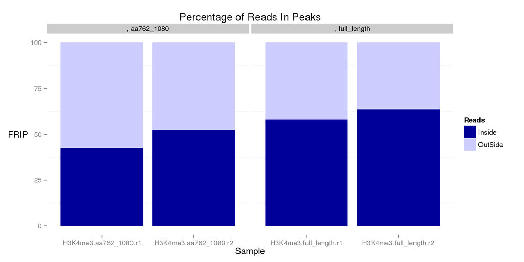

```r
plotFrip(qc)
```

The summit of the peaks are enriched for signal. Though this also highlights the difference between the truncated Set1 replicates.

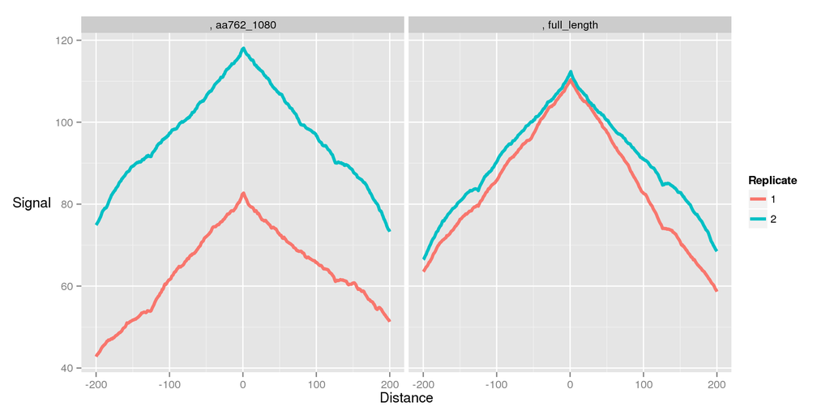

```r
plotPeakProfile(qc)
```

Lastly, all the samples have a cross correlation greater than 1, indicating enrichment. Strangely, the cross correlation does not appear normally distributed as normal. This may be related to why I had to decrease the lower threshold from 5 to 3 when trying to find paired peaks. Maybe I could try specifying `--no-model --shiftsize=147` to be the size of one nucleosome.

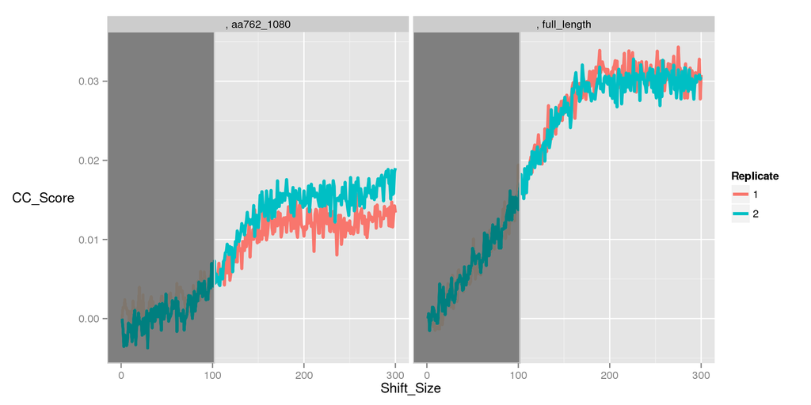

```r
plotCC(qc)
```

## Test for differential H3K4me3

Contruct dba object.

```r
d <- dba(sampleSheet = samplesheet,
         minOverlap = 2, # Peaks have to be identified in at least
                         # 2 of the 4 samples
         # Lots of configuration options. I only comment when I change
         # the default setting.
         config = data.frame(RunParallel = TRUE,
                             reportInit = "DBA",
                             DataType = DBA_DATA_FRAME, # Return df instead of granges
                             AnalysisMethod = DBA_EDGER,
                             minQCth = 10, # Use min read qual of 10 instead of 15
                             fragmentSize = 125,
                             bCorPlot = FALSE, # Don't plot automatically
                             th = .1,
                             bUsePval=FALSE),
         bCorPlot = FALSE)
```

```
## H3K4me3.aa762_1080.r1  aa762_1080   1 macs
## H3K4me3.aa762_1080.r2  aa762_1080   2 macs
## H3K4me3.full_length.r1  full_length   1 macs
## H3K4me3.full_length.r2  full_length   2 macs
```

Because there are only 4 samples total, the minimum requirement that a peak is observed in at least two samples seems overly stringent. `dba.overlap` displays the number of peaks found in at least one sample, two samples, etc.

```r
overlap <- dba.overlap(d, mode = DBA_OLAP_RATE)
overlap
```

```
## [1] 4038 3560 2837 2249
```

By requiring a peak is observed in at least two samples, I lose 478 peaks. I redefine the dba requiring a peak is only observed in one sample.

```r
d <- dba(sampleSheet = samplesheet,
         minOverlap = 1, # Peaks have to be identified in at least
                         # 1 of the 4 samples
         # Lots of configuration options. I only comment when I change
         # the default setting.
         config = data.frame(RunParallel = TRUE,
                             reportInit = "DBA",
                             DataType = DBA_DATA_FRAME, # Return df instead of granges
                             AnalysisMethod = DBA_EDGER,
                             minQCth = 10, # Use min read qual of 10 instead of 15
                             fragmentSize = 125,
                             bCorPlot = FALSE, # Don't plot automatically
                             th = .1,
                             bUsePval=FALSE),
         bCorPlot = FALSE)
```

```
## H3K4me3.aa762_1080.r1  aa762_1080   1 macs
## H3K4me3.aa762_1080.r2  aa762_1080   2 macs
## H3K4me3.full_length.r1  full_length   1 macs
## H3K4me3.full_length.r2  full_length   2 macs
```

Visualize the relationship between the samples using the concordance in binding sites.

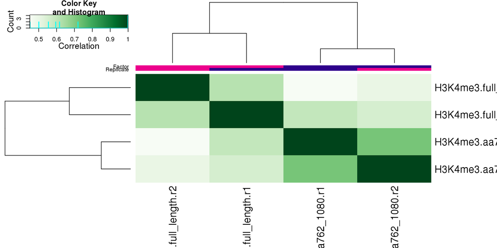

```r
dba.plotHeatmap(d)
```

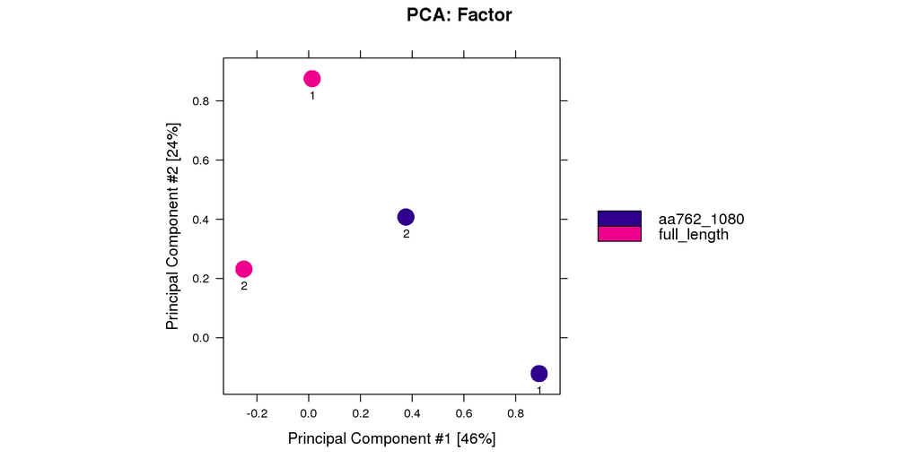

```r
dba.plotPCA(d, label = DBA_REPLICATE)
```

Clearly the full length and truncated Set1 samples are more closely related to their replicates than each other. The first PC is the split between the two. However, it is clear in the second PC that there is substantial difference between replicates.

Now I count the reads in each peak and again compare the samples using this more quantitative measurement.

```r
d = dba.count(d)
```

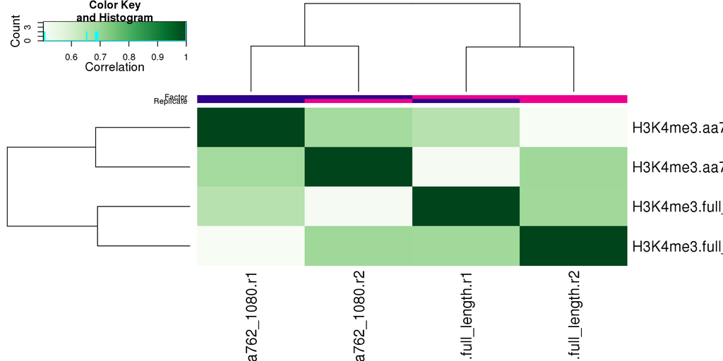

```r
dba.plotHeatmap(d)
```

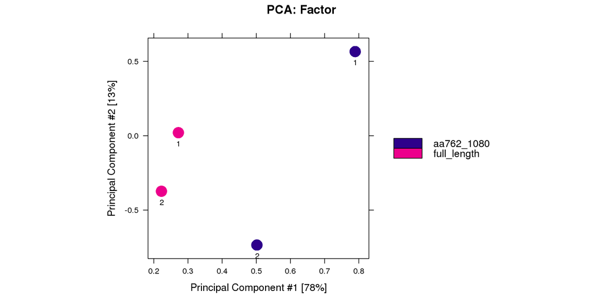

```r
dba.plotPCA(d, label = DBA_REPLICATE)
```

Now the split in PC1 between the two Set1 versions is even stronger. Also, the replicates for the full length now cluster much closer together on PC2, and the truncated Set1 replicates are even further apart.

Perform the differential expression using edgeR.

```r
d = dba.contrast(d, categories = DBA_FACTOR, minMembers = 2)
d = dba.analyze(d)
results = dba.report(d)
head(results)
```

```
##       Chr  Start    End     Conc Conc_aa762_1080 Conc_full_length
## 3392  XVI 339899 340489 7.014153       0.3262861         8.007139
## 2525 XIII 335124 335735 6.994233       0.3262861         7.987121
## 3242   XV 904555 905342 6.671539       0.3262861         7.662639
## 940    IX 322156 322791 6.614510       0.3262861         7.605250
## 3372  XVI 285795 286373 6.513551       0.3262861         7.503617
## 915    IX 249987 250541 6.436588       0.3262861         7.426109
##           Fold      p-value          FDR
## 3392 -7.680853 2.880052e-16 6.084653e-13
## 2525 -7.660835 3.418344e-16 6.084653e-13
## 3242 -7.336353 4.428312e-15 5.254931e-12
## 940  -7.278964 6.978198e-15 6.210596e-12
## 3372 -7.177331 1.936322e-14 1.378661e-11
## 915  -7.099823 2.866958e-14 1.701062e-11
```

There are 191 regions with diffential H3K4me3 reads between the two Set1 proteins. Of these, 186 of the regions have more H3K4me3 reads in the yeast samples with the fully functional Set1. This can be visualized with the MA plots below. The red dots are significantly different regions.

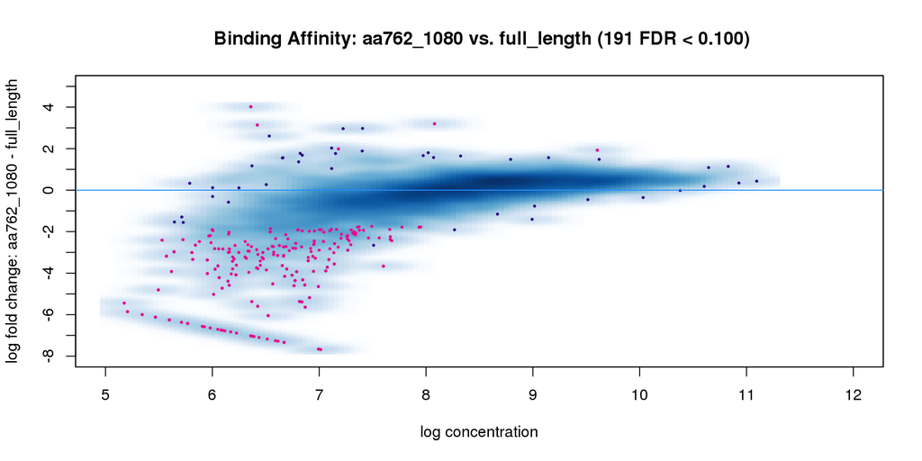

```r
dba.plotMA(d)
```

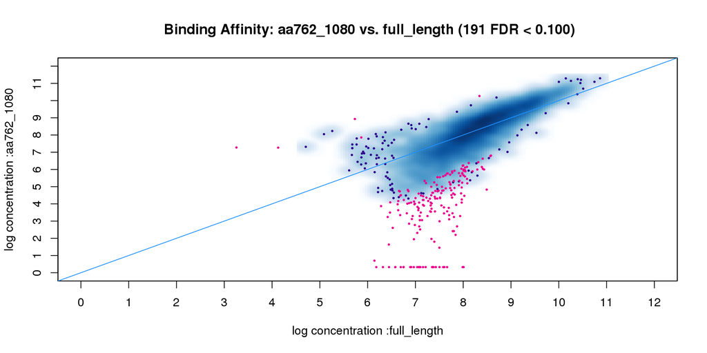

```r
dba.plotMA(d, bXY = TRUE)
```